## Complejo racial cónico

El Grupo Cónico es un conjunto de razas de maíz endémicas de México que se caracterizan por tener mazorcas cónicas o piramidales. Estas razas se distribuyen principalmente en regiones con elevaciones superiores a los 2,000 m en el centro del país, y son utilizadas para la producción de diversos alimentos como tortillas, tamales, antojitos y palomitas, entre otros. Además, en la zona de cultivo de estas razas también se pueden encontrar poblaciones naturales de teocintle, una especie de maíz silvestre, que se asemeja en aspecto a las razas del Grupo Cónico y que aporta importantes ventajas genéticas y de forraje para el maíz.

Las razas del Grupo Cónico tienen características comunes en la forma de la mazorca, el número de hileras de grano y los tipos de texturas de granos. Además, estas razas son importantes para la economía agrícola del centro de México, ya que se utilizan para la producción de alimentos y subproductos como forraje y hojas de tamal. Sin embargo, la similitud en aspecto entre las razas del Grupo Cónico y el teocintle dificulta su diferenciación en los campos de cultivo donde crecen juntos, aunque también representa una importante fuente de flujo genético y forraje para el maíz.

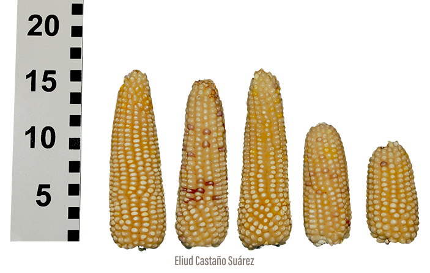

###### Información de CONABIO. 2020. [Grupo cónico](https://www.biodiversidad.gob.mx/diversidad/alimentos/maices/razas/grupo-conico). Comisión Nacional para el Conocimiento y Uso de la Biodiversidad, Cd. de México. México.